# Designing the action button

In the next two lessons, we will design and code the menu to choose a combat action during your turn. It will list available actions on the corresponding battler and emit a signal along with the selected one.

[figure not shown]

We will put the previous lesson’s tips into practice by splitting it into three nested components:

1. The action button.
2. The list of action buttons, containing one or more action buttons and a selection arrow.
3. And the menu that mostly opens, closes, and tells which action was selected.

You will also see two patterns in all our UI classes: I decided to name them all `UI*`, for example, `UIActionButton`, and they tend to have a `setup()` function to pass data to each component and initialize it.

In this part, we will design the action button.

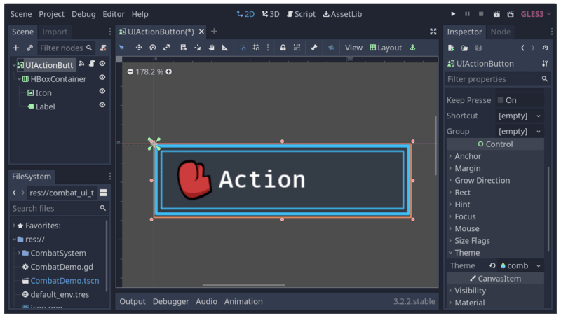

## Designing an action button

Let’s start with the action button. Please create a new scene with a *TextureButton* named *UIActionButton* as its root. The node will detect when the user clicks, touches, or presses it with a key.

In the *FileSystem* dock, search for `menu_action_`. We prepared four textures to assign to the texture button. In the *Inspector*, expand the *Textures* section and drag and drop the textures corresponding to each button state. For example, `menu_action_bg.png` corresponds to the *Textures -> Normal* state.

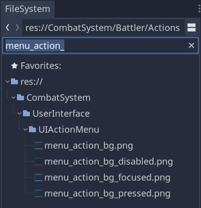

There are four textures to assign to the button.

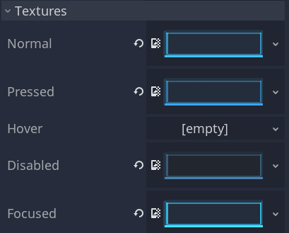

If you haven’t already downloaded the project, you can find it in the course downloads at the bottom of every page.

Our *TextureButton* allows us to have a custom-looking button, but it only gives us a background texture to work with. Let’s add support for an icon and a label.

Add an *HBoxContainer* to align the image and text horizontally. As its children, add a *TextureRect* named *Icon* and a *Label*. Your scene tree should look like the following.

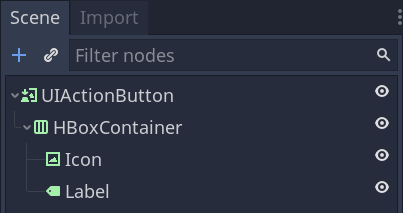

Select the *HBoxContainer* and, in the toolbar, apply *Layout -> Full Rect* to resize it and anchor it to the button’s corners.

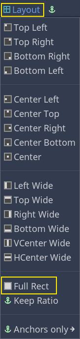

Then, drag the node’s scale handles to give it some margins.

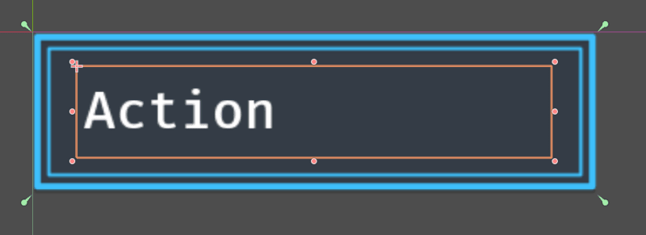

In the *Inspector*, toggle on *Rect -> Clip Content* so when you experiment with icons and text, they won’t change the node’s size even if they are big.

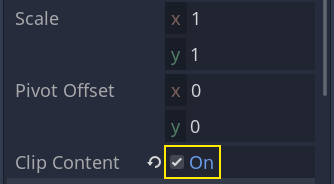

You can add some default text to the *Label* to see it’s too small by default. We also included a test icon, `icon_punch.svg`, that you can use for the *Icon* node’s texture for testing purposes.

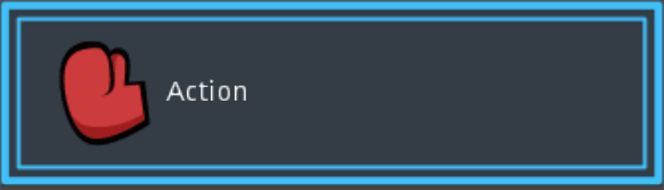

## Replacing the default font with a theme

To replace the default font, we will use a theme resource. Doing so allows us to reuse the font across the game’s interfaces.

In the *FileSystem* dock, right-click on some directory and select *New Resource…*.

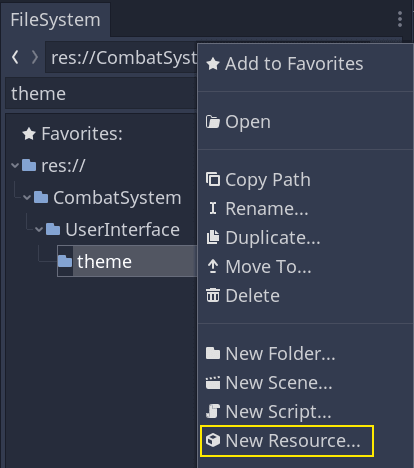

Create a new *Theme* and save it as `combat_ui_theme.tres`. In the *Inspector*, click the *Default Font* property and create a new *DynamicFont*. Expand the resource to see its settings.

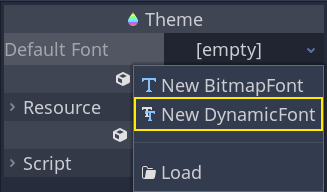

Look for the file `fira_mono_medium.ttf` in the *FileSystem* dock and drag it onto *Font -> Font Data*. You can then set the *Settings -> Size* to the value that works best for you. I went with *32* pixels.

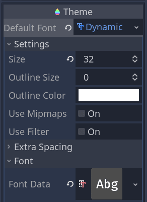

Select the *UIActionButton* and drag the theme resource onto the *Theme -> Theme* property. You should see the *Label*’s text update.

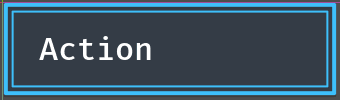

With this, we have our scene ready to code.

## Coding the UIActionButton

Attach a new script to the *UIActionButton* node with the following code. Below, notice how the button has no access to the battler to which it’s associated. It only has access to the `ActionData` in its `setup()` function. In a more complex project, with a large team, you may want a complete separation between the UI and the rest of the game. In that case, you would not pass the `ActionData` directly but instead, pass a dictionary or a new object containing only the data the button needs.

```
# Individual button representing one combat action.
extends TextureButton

# We store references to the nodes we access in the class, as usual.
onready var _icon_node: TextureRect = $HBoxContainer/Icon
onready var _label_node: Label = $HBoxContainer/Label


# To call from a parent UI widget. Initializes the button.
func setup(action: ActionData, can_be_used: bool) -> void:
    # In a parent node you may call `setup()` before adding the button as a child.
    # If that is the case, we need to pause execution until the button is ready.
    if not is_inside_tree():
        yield(self, "ready")
    # Only update the icon's texture if the action data inlcudes an icon.
    if action.icon:
        _icon_node.texture = action.icon
    _label_node.text = action.label
    # The button has no notion of the battler's energy and the action's cost.
    # We will tell it if the player can use the action or not. If not, the button should be disabled.
    disabled = not can_be_used


# When pressing the button, we release its focus. Doing so prevents the player from
# pressing two action buttons or from pressing one twice.
func _on_pressed() -> void:
    release_focus()
```

We finally need to connect the button’s *pressed* signal to the `_on_pressed()` function. You can do so using the editor’s Node dock.

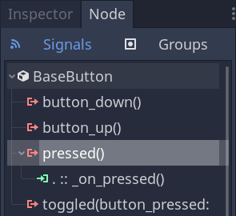

In the next part, we will design and code the action list and the action menu.